# Class Survey

Jonathan Teo

10/17/18

# Introduction

We start by loading the data into 2 data frames

```r
library(readr)
Sec02 <- read_csv("Class_Survey_Sec02.csv")
Sec23 <- read_csv("Class_Survey_Sec23.csv")
Sec02 <- mutate(Sec02,sect="PM")
Sec23 <- mutate(Sec23,sect="Eve")
alldat <- bind_rows(Sec02,Sec23)
```

```r
write.csv(x=alldat,file="alldata.csv")
```

# Methods

1. whether there are differences in average age between the two classes

We took the data and merge the two classes data. Then we produced a summary data called alldat that allowed us to section the two classes into pm and eve, we then compared the age average. that allowed us to answer our question. There are approximately 40 responses in each data set and 83 overal.

3. differences between time up and down the stairs between guys and gals

We took both datas and merged them together. We produced a summary graph called “alldat”. The difference between guys and gals is that the males went up the stairs quicker than the females

# Results

## Descriptive Results

### Graphical Descriptive Results

Q1:

Once we graphed our data, we found that there was a higher age group in the evening class in comparsion to the pm class.

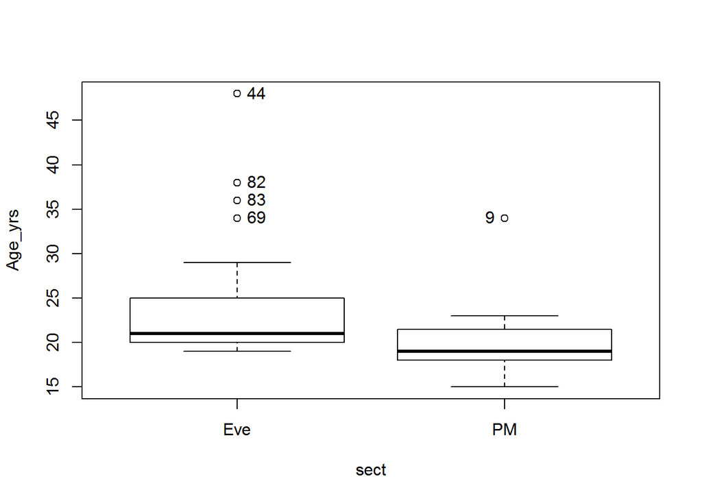

```
## [1] "44" "69" "82" "83" "9"
```

```r
Boxplot(Age_yrs~sect, data=alldat, id=list(method="y"))
```

Q3:

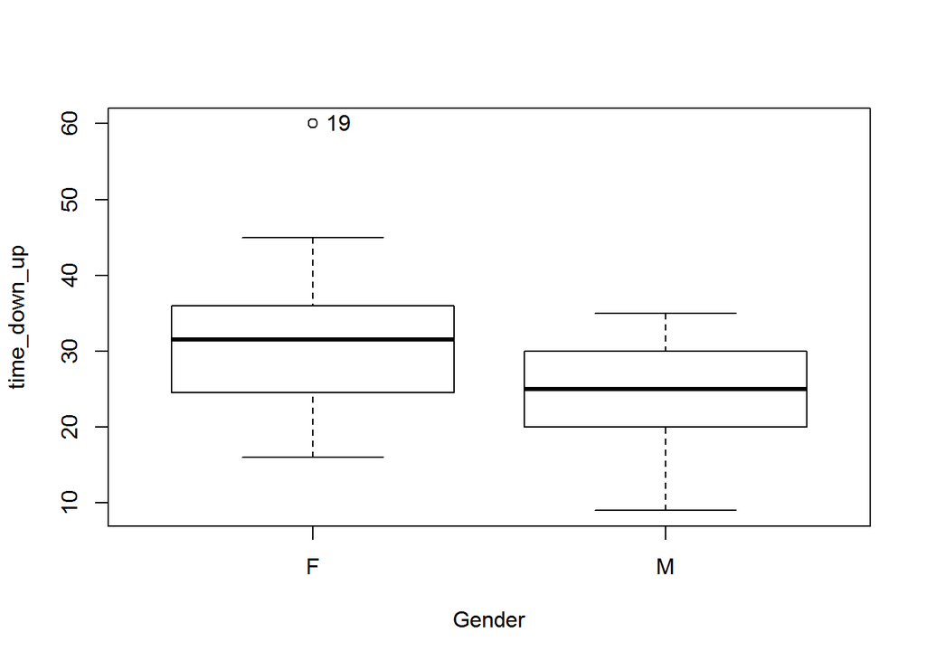

```
## [1] "19"
```

```r
Boxplot(time_down_up~Gender, data=alldat, id=list(method="y"))
```

### Numerical Descriptive Results

Q1:

```r
numSummary(alldat[,"Age_yrs", drop=FALSE], groups=alldat$sect, statistics=c("mean", "sd", "IQR",
   "quantiles"), quantiles=c(0,.25,.5,.75,1))
```

```
##         mean       sd  IQR 0% 25% 50%   75% 100% Age_yrs:n Age_yrs:NA
## Eve 24.14815 7.150598 5.00 19  20  21 25.00   48        27         15
## PM  19.91667 3.549852 3.25 15  18  19 21.25   34        24         17
```

Q3:

```r
numSummary(alldat[,"time_down_up", drop=FALSE], groups=alldat$Gender, statistics=c("mean", "sd", "IQR",
   "quantiles"), quantiles=c(0,.25,.5,.75,1))
```

```
##       mean       sd   IQR 0%   25%  50% 75% 100% time_down_up:n
## F 30.64286 9.810102 11.25 16 24.75 31.5  36   60             28
## M 24.05000 7.451422 10.00  9 20.00 25.0  30   35             20
##   time_down_up:NA
## F               3
## M               3
```

From the numerical summary, it looks like the average speed of males going down and up the stairs are faster than females.

## Inferential Results

Q1:

```r
t.test(Age_yrs~sect, alternative='two.sided', conf.level=.95, var.equal=FALSE, data=alldat)
```

```
##
##  Welch Two Sample t-test
##
## data:  Age_yrs by sect
## t = 2.7208, df = 39.025, p-value = 0.009678
## alternative hypothesis: true difference in means is not equal to 0
## 95 percent confidence interval:
##  1.085755 7.377208
## sample estimates:
## mean in group Eve  mean in group PM
##          24.14815          19.91667
```

```r
source("bootstrap.R")
#need a to have just the age data from section 2
a=na.omit(alldat$Age_yrs[alldat$sect=="F"])
b=na.omit(alldat$Age_yrs[alldat$sect=="M"])
bootstrp(a,b,1000)
```

```
## Difference was  NaN
##  probability of observing =  NA
```

[output not shown]

[output cut: 42 more lines]

Q3:

```r
t.test(time_down_up~Gender, alternative='two.sided', conf.level=.95, var.equal=FALSE, data=alldat)
```

```
##
##  Welch Two Sample t-test
##
## data:  time_down_up by Gender
## t = 2.6449, df = 45.785, p-value = 0.01116
## alternative hypothesis: true difference in means is not equal to 0
## 95 percent confidence interval:
##   1.574794 11.610920
## sample estimates:
## mean in group F mean in group M
##        30.64286        24.05000
```

From the means above the t.test, it dipicts that overall, males have a faster time going down and up the stairs

```r
source("bootstrap.R")
#need a to have just the age data from section 2
a=na.omit(alldat$time_down_up[alldat$Gender=="F"])
b=na.omit(alldat$time_down_up[alldat$Gender=="M"])
bootstrp(a,b,1000)
```

```
## Difference was  6.592857
##  probability of observing =  0.011
```

[output not shown]

[output cut: 198 more lines]

# Discussion and Conclusion

Question 1: From the results and data above, it seems the evening class has a higher average of age compared to the pm class

Question 3: From the results and data above, it seems males have n overall faster time going up and down the stairs compared to females